# SAP projekt - Analiza poadataka o igračima NHL lige

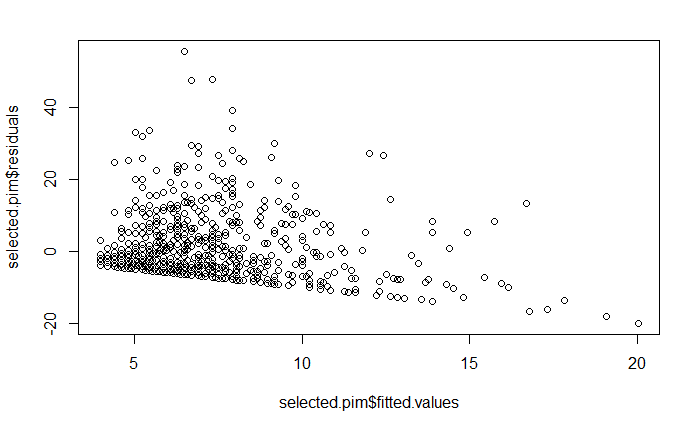

```r
plot(selected.pim$fitted.values,selected.pim$residuals) #reziduale je dobro prikazati u ovisnosti o procjenama modela
```

```r
#KS test na normalnost
ks.test(rstandard(fit.pim),'pnorm')
```

```
ties should not be present for the Kolmogorov-Smirnov test
```

```
    One-sample Kolmogorov-Smirnov test

data:  rstandard(fit.pim)
D = 0.19493, p-value < 2.2e-16
alternative hypothesis: two-sided
```

```r
require(nortest)
lillie.test(rstandard(fit.pim))
```

```
    Lilliefors (Kolmogorov-Smirnov) normality test

data:  rstandard(fit.pim)
D = 0.19473, p-value < 2.2e-16
```

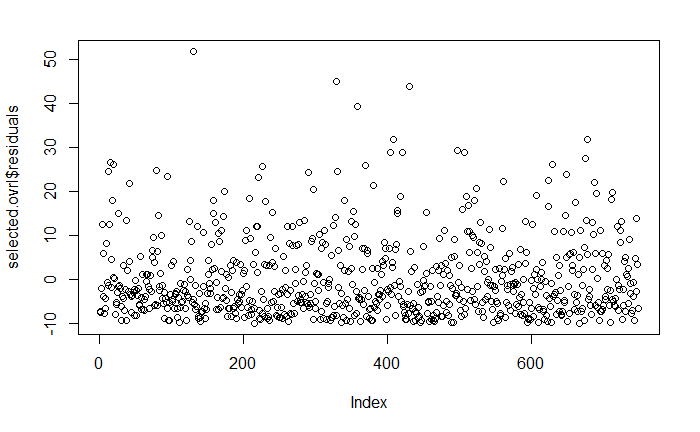

```r
####  Overall
selected.ovrl = fit.ovrl

plot(selected.ovrl$residuals)
```

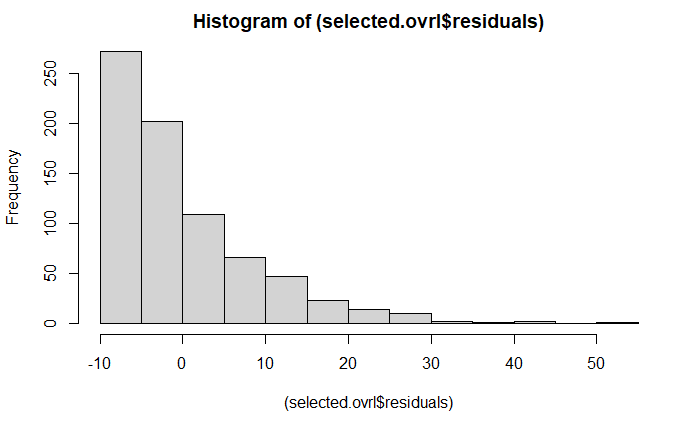

```r
#histogram je vrlo interpretativan
hist((selected.ovrl$residuals))
```

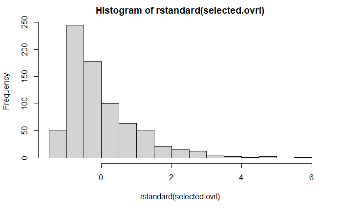

```r
hist(rstandard(selected.ovrl))
```

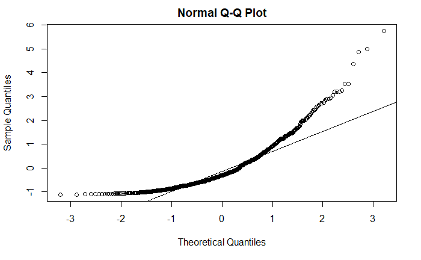

```r
#q-q plot reziduala s linijom normalne distribucije
qqnorm(rstandard(selected.ovrl))
qqline(rstandard(selected.ovrl))
```

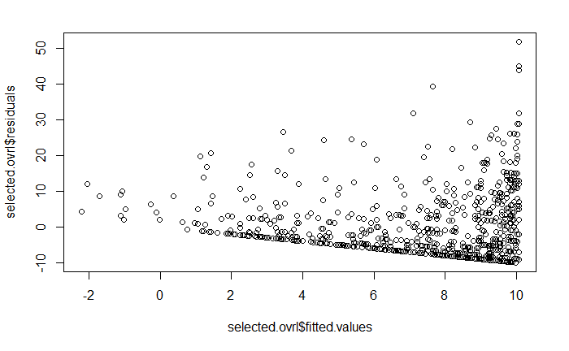

```r
plot(selected.ovrl$fitted.values,selected.ovrl$residuals)
```

```r
#KS test na normalnost
ks.test(rstandard(fit.ovrl),'pnorm')
```

```
ties should not be present for the Kolmogorov-Smirnov test
```

```
    One-sample Kolmogorov-Smirnov test

data:  rstandard(fit.ovrl)
D = 0.14451, p-value = 5.185e-14
alternative hypothesis: two-sided
```

```r
require(nortest)
lillie.test(rstandard(fit.ovrl))
```

```
    Lilliefors (Kolmogorov-Smirnov) normality test

data:  rstandard(fit.ovrl)
D = 0.14455, p-value < 2.2e-16
```

Kao i očekivano, broj postignutih golova i asistencija te pozicija na draftu (niža pozicija je bolja pozicija) pozitivno utječu na broj koliko je puta igrač izabran u najbolji tim, te tu uočavamo uzročno posljedične veze. Kod PIM (minute isključenja) smo došli do zaključka da ne utječu previše na osvojene nagrade, što se može najbolje vidjeti iz scatter plota.

———————-ZAKLJUČAK RADA—————————- Tijekom čitave ove analize pokušali smo pomoću situacija iz svakodnevice motivirati zanimljive probleme koje smo preslikali na naš skup podataka iz NHL,te smo prilikom rješavanja pojedinih problema izračunali neke korisne mjere,primjenili neke korisne modele i testove te isto tako napravili vizualizaciju odgovora na naše probleme.Da bi smo uspješno savladali ove probleme poslužili smo se znanjem Statističke Analize Podataka kojeg smo osim upotrebe još dodatno utvrdili.